# Introduction to Computational Finance Summer 2022, Lab 1

Due Jul 1st, 2022

6/18/2022

# Readings

- EZ lecture notes on review of probability theory and random variables.
- Ruppert, chapter 2 (Returns) and Appendix (probability review)
- A Beginner’s Guide to R, chapters 3-7.
- R Cookbook, chapters 8 (probability) and 10 (graphics)

# Programs and Data

- `probReview.xls` (canvas)
- `probReview.r` (canvas)

# Instructions

In this lab you will become more familiar with random variables and probability distributions. Try to do all of the calculations and plots in R. You can also do everything in Excel too. You will find the examples in `probReview.R` and `probReview.xls` to be helpful for some of the exercises that follow.

# Exercises

1. Suppose $X$ is a normally distributed random variable with mean $0.05$ and variance $(0.10)^2$. Compute the following

```r
#   $\Pr(X > 0.10)$
1 - pnorm(0.10, mean=0.05, sd=0.10)
```

```
## [1] 0.3085375
```

```r
#   $\Pr(X < -0.10)$
pnorm(-0.10, mean=0.05, sd=0.10)
```

```
## [1] 0.0668072
```

```r
#   $\Pr(-0.05 < X < 0.15)$
pnorm(0.15, mean=0.05, sd=0.10) - pnorm(-0.05, mean=0.05, sd=0.10)
```

```
## [1] 0.6826895
```

```r
#   $1\% \text{ quantile}, q_{01}$
qnorm(0.01, mean=0.05, sd=0.10)
```

```
## [1] -0.1826348
```

```r
#   $5\% \text{ quantile}, q_{05}$
qnorm(0.05, mean=0.05, sd=0.10)
```

```
## [1] -0.1144854
```

```r
#   $95\% \text{ quantile } q_{95}$
qnorm(0.95, mean=0.05, sd=0.10)
```

```
## [1] 0.2144854
```

```r
#   $99\% \text{ quantile }, q_{99}$
qnorm(0.99, mean=0.05, sd=0.10)
```

```
## [1] 0.2826348
```

Hint: you can use the R functions `pnorm()` and `qnorm()` to answer these questions.

2. Let $X$ denote the monthly return on Microsoft Stock and let $Y$ denote the monthly return on Starbucks stock. Assume that $X \sim N(0.05, (0.10)^{2}) \text{ and } Y \sim N(0.025, (0.05)^{2}).$
- Using a grid of values between -$0.25$ and $0.35$, plot the normal curves for $X$ and $Y$. Make sure that both normal curves are on the same plot.

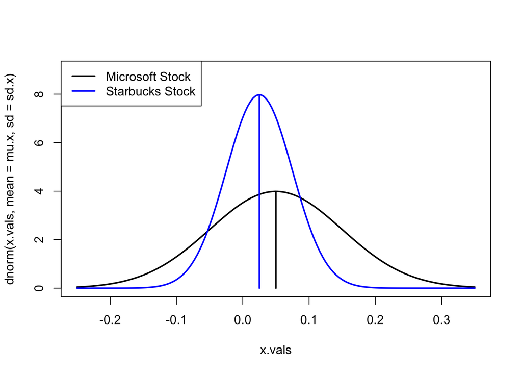

```r
mu.x = 0.05
sd.x = 0.10
mu.y = 0.025
sd.y = 0.05

x.vals = seq(-0.25, 0.35, length=150)
# plot for X
plot(x.vals, dnorm(x.vals, mean=mu.x, sd=sd.x), type="l", lwd=2,
     ylim=c(0,9), col="black")
segments(mu.x, 0, mu.x, dnorm(mu.x, mu.x, sd.x), lwd=2, col="black")
# plot for Y
lines(x.vals, dnorm(x.vals, mean=mu.y, sd=sd.y), type="l", lwd=2, col="blue")
segments(mu.y, 0, mu.y, dnorm(mu.y, mu.y, sd.y), lwd=2, col="blue")
# X: Microsoft Stock; Y: Starbucks Stock
legend(x="topleft", legend=c("Microsoft Stock", "Starbucks Stock"), lwd=2,
       col=c("black", "blue"))
```

- Comment on the risk-return tradeoffs for the two stocks.

```r
#  The normal distribution of Microsoft Stock(X) has a higher mean return but also higher  #    stand deviation than Starbucks Stock(Y). The higher return with higher risk of variance     are trade-offs for the two stocks.
```

3. Let $R$ denote the simple monthly return on Microsoft stock and let $W_0$ denote initial wealth to be invested over the month. Assume that $R \sim N(0.04, (0.09)^{2}) \text{ and that } W_0 = \$100,000$.
- Determine the $1\%$ and $5\%$ value-at-risk (VaR) over the month on the investment. That is, determine the loss in investment value that may occur over the next month with $1\%$ probability and with $5\%$ probability.

```r
mu.R = 0.04
sd.R = 0.09
W0 = 100000
#  loss in investment value that may occur over the next month with 1% probability
W0*qnorm(0.01, mean=mu.R, sd=sd.R)
```

```
## [1] -16937.13
```

```r
#  loss in investment value that may occur over the next month with 5% probability
W0*qnorm(0.05, mean=mu.R, sd=sd.R)
```

```
## [1] -10803.68
```

4. Let $r$ denote the continuously compounded monthly return on Microsoft stock and let $W_0$ denote initial wealth to be invested over the month. Assume that $r \sim \text{ iid } N(0.04, (0.09)^2)$ and that $W_0 = \$100,000$.
- Determine the $1\%$ and $5\%$ value-at-risk (VaR) over the month on the investment. That is, determine the loss in investment value that may occur over the next month with $1\%$ probability and with $5\%$ probability. (Hint: compute the $1\%$ and $5\%$ quantile from the Normal distribution for $r$ and then convert continuously compounded return quantile to a simple return quantile using the transformation)

```r
mu.r = 0.04
sd.r = 0.09
W0 = 100000

#  loss in investment value that may occur over the next month with 1% probability
q_r_0.01 = qnorm(0.01, mean=mu.r, sd=sd.r)
q_R_0.01 = exp(q_r_0.01) - 1
W0*q_R_0.01
```

```
## [1] -15580.46
```

```r
#  loss in investment value that may occur over the next month with 5% probability
q_r_0.05 = qnorm(0.05, mean=mu.r, sd=sd.r)
q_R_0.05 = exp(q_r_0.05) - 1
W0*q_R_0.05
```

```
## [1] -10240.55
```

- Determine the $1\%$ and $5\%$ value-at-risk (VaR) over the year on the investment. Hint: to answer this question, you must determine the normal distribution that applies to the annual (12 month) continuously compounded return. This was done as an example in class.

```r
mu.12r = 12*0.04
sd.12r = 0.09*sqrt(12)

#  loss in investment value that may occur over the next year with 1% probability
q_12r_0.01 = qnorm(0.01, mean=mu.12r, sd=sd.12r)
q_12R_0.01 = exp(q_12r_0.01) - 1
W0*q_12R_0.01
```

```
## [1] -21751.73
```

```r
#  loss in investment value that may occur over the next year with 5% probability
q_12r_0.05 = qnorm(0.05, mean=mu.12r, sd=sd.12r)
q_12R_0.05 = exp(q_12r_0.05) - 1
W0*q_12R_0.05
```

```
## [1] -3228.205
```

5. In this question, you will examine the chi-square and Student’s t distributions.
- On the same graph, plot the probability curves of chi-squared distributed random variables with 1, 2, 5 and 10 degrees of freedom. Use different colors and line styles for each curve.

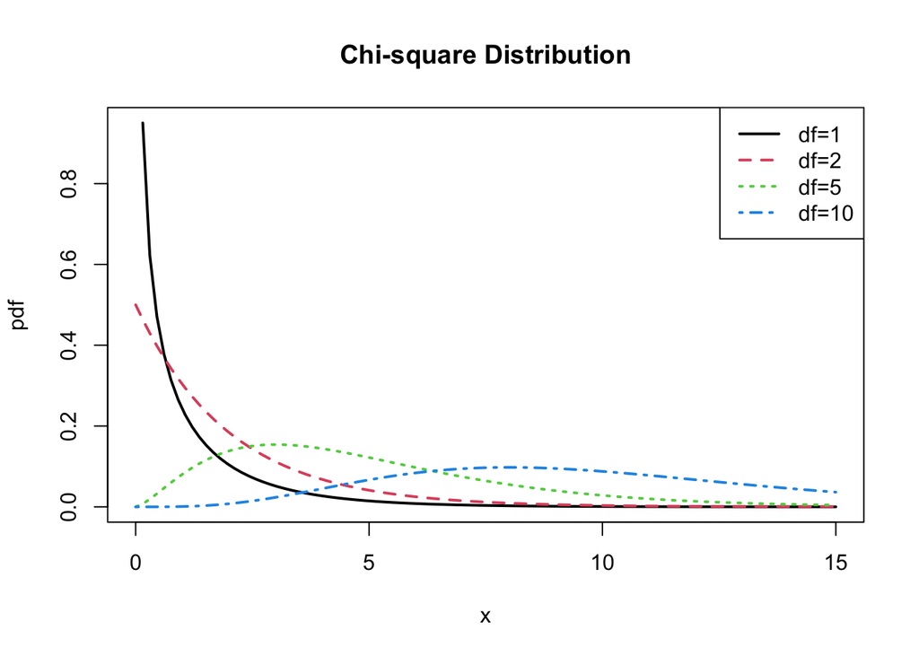

```r
# Chi-square distribution
x.vals = seq(0, 15, length=100)

plot(x.vals, dchisq(x.vals, df=1), type="l", lwd=2, ylab="pdf", xlab="x",lty=1, col=1)
lines(x.vals, dchisq(x.vals, df=2), type="l", lwd=2, lty=2, col=2)
lines(x.vals, dchisq(x.vals, df=5), type="l", lwd=2, lty=3, col=3)
lines(x.vals, dchisq(x.vals, df=10), type="l", lwd=2, lty=4, col=4)
legend(x="topright", legend=paste("df=", c(1,2,5,10), sep=""), lty=1:4, col=1:4, lwd=2)
title("Chi-square Distribution")
```

- On the same graph, plot the probability curves of Student’s t distributed random variables with 1, 2, 5 and 10 degrees of freedom. Also include the probability curve for the standard normal distribution. Use different colors and line styles for each curve.

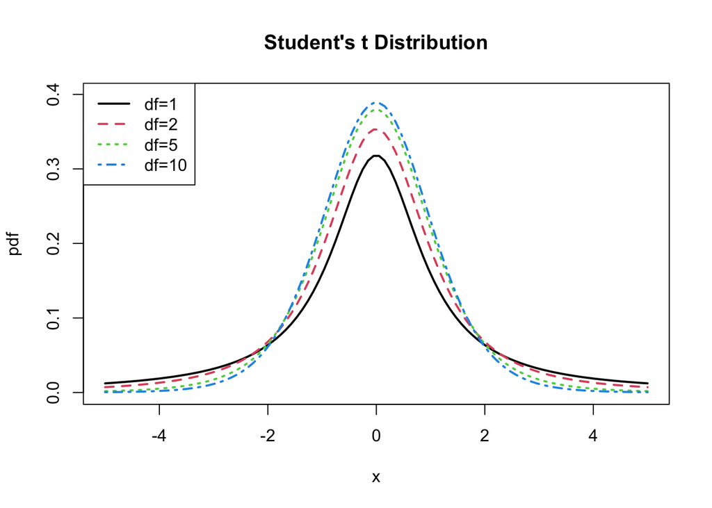

```r
# Student’s t distribution
x.vals = seq(-5, 5, length=100)
ub = max( c(dt(0, df=c(1,5,10,60)), dnorm(0)) )

plot(x.vals, dt(x.vals, df=1), type="l", lwd=2, ylim=c(0, ub), ylab="pdf", xlab="x",lty=1, col=1)
lines(x.vals, dt(x.vals, df=2), type="l", lwd=2, lty=2, col=2)
lines(x.vals, dt(x.vals, df=5), type="l", lwd=2, lty=3, col=3)
lines(x.vals, dt(x.vals, df=10), type="l", lwd=2, lty=4, col=4)
legend(x="topleft", legend=paste("df=", c(1,2,5,10), sep=""), lty=1:4, col=1:4, lwd=2)
title("Student's t Distribution")
```

6. Consider the following joint distribution of $X$ and $Y$:

| X-Y | 1 | 2 | 3 |
| --- | --- | --- | --- |
| 1 | 0.1 | 0.2 | 0 |
| 2 | 0.1 | 0 | 0.2 |
| 3 | 0 | 0.1 | 0.3 |

- 1. Find the marginal distributions of $X$ and $Y$. Using these distributions, compute $E[X]$, $var(X)$, $SD(X)$, $E[Y]$, $var(Y)$ and $SD(Y)$.
- 2. Compute $\mathrm{COV}(X,Y)$ and $\mathrm{CORR}(X,Y)$

```r
# (a)
x1y1 = 0.1
x1y2 = 0.2
x1y3 = 0
x2y1 = 0.1
x2y2 = 0
x2y3 = 0.2
x3y1 = 0
x3y2 = 0.1
x3y3 = 0.3

# marginal distributions of Y=1:
y1 = (x1y1+x2y1+x3y1)/1
y1
```

```
## [1] 0.2
```

```r
# marginal distributions of Y=2:
y2 = (x1y2+x2y2+x3y2)/1
y2
```

```
## [1] 0.3
```

```r
# marginal distributions of Y=3:
y3 = (x1y3+x2y3+x3y3)/1
y3
```

```
## [1] 0.5
```

```r
# marginal distributions of X=1:
x1 = (x1y1+x1y2+x1y3)/1
x1
```

```
## [1] 0.3
```

```r
# marginal distributions of X=2:
x2 = (x2y1+x2y2+x2y3)/1
x2
```

```
## [1] 0.3
```

```r
# marginal distributions of X=3:
x3 = (x3y1+x3y2+x3y3)/1
x3
```

```
## [1] 0.4
```

```r
x.vals = 1:3
# E[X]
mu.x = sum(x.vals * c(x1,x2,x3))
mu.x
```

```
## [1] 2.1
```

```r
# Var[X]
var.x = sum((x.vals - mu.x)^2 * c(x1,x2,x3))
var.x
```

```
## [1] 0.69
```

```r
#sd[X]
sd.x = sqrt(var.x)
sd.x
```

```
## [1] 0.8306624
```

```r
y.vals = 1:3
# E[Y]
mu.y = sum(y.vals * c(y1,y2,y3))
mu.y
```

```
## [1] 2.3
```

```r
# Var[Y]
var.y = sum((y.vals - mu.y)^2 * c(y1,y2,y3))
var.y
```

```
## [1] 0.61
```

```r
#sd[Y]
sd.y = sqrt(var.y)
sd.y
```

```
## [1] 0.781025
```

```r
# (b)
# COV(X,Y)
cov.xy = sum((1-mu.x)*(1-mu.y)*x1y1, (2-mu.x)*(1-mu.y)*x2y1, (3-mu.x)*(1-mu.y)*x3y1,
             (1-mu.x)*(2-mu.y)*x1y2, (2-mu.x)*(2-mu.y)*x2y2, (3-mu.x)*(2-mu.y)*x3y2,
             (1-mu.x)*(3-mu.y)*x1y3, (2-mu.x)*(3-mu.y)*x2y3, (3-mu.x)*(3-mu.y)*x3y3)
cov.xy
```

```
## [1] 0.37
```

```r
#CORR(X,Y)
corr.xy = cov.xy / (sd.x * sd.y)
corr.xy
```

```
## [1] 0.5703117
```

- Are $X$ and $Y$ independent? Fully justify your answer.

```r
#  No. If X and Y are independent, then COV(X,Y) = 0. but from (b), we've calculated that   #      COV(X,Y) = 0.37. Therefore, X and Y are NOT independent.
```

7. Consider a one month investment in two Northwest stocks: Amazon and Costco. Suppose you buy Amazon and Costco at the end of September at $P_{A,t-1} = \$38.23, P_{C,t-1} = \$41.11$ and then sell at the end of the October for $P_{A,t} = \$41.29, P_{C,t} = \$41.74$ . (Note: these are actual closing prices for 2004 taken from Yahoo!)

*(a) What are the simple monthly returns for the two stocks?* (b) What are the continuously compounded returns for the two stocks? *(c) Suppose Costco paid a $\$0.10$ per share cash dividend at the end of October. What is the monthly simple total return on Costco? What is the monthly dividend yield?* (d) Suppose the monthly returns on Amazon and Costco from question (a) above are the same every month for 1 year. Compute the simple annual returns as well as the continuously compounded annual returns for the two stocks. *(e) At the end of September, 2004, suppose you have $\$10,000$ to invest in Amazon and Costco over the next month. If you invest $\$8,000$ in Amazon and $\$2,000$ in Costco, what are your portfolio shares, $x_A \text{ and } x_C$. (Assume partial share purchases are possible)* (f) Continuing with the previous question, compute the monthly simple return and the monthly continuously compounded return on the portfolio. Assume that Costco does not pay a dividend.

```r
p.a.t_1 = 38.23
p.c.t_1 = 41.11
p.a.t = 41.29
p.c.t = 41.74

#(a)
# simple monthly return for Amazon stock
A.R = (p.a.t - p.a.t_1) / p.a.t_1
A.R
```

```
## [1] 0.08004185
```

```r
# simple monthly return for Costco stock
C.R = (p.c.t - p.c.t_1) / p.c.t_1
C.R
```

```
## [1] 0.01532474
```

```r
#(b)
# continuously compounded return for the Amazon stock
A.continuous.R = log(A.R + 1)
A.continuous.R
```

```
## [1] 0.07699979
```

```r
# continuously compounded return for the Costco stock
C.continuous.R = log(C.R + 1)
C.continuous.R
```

```
## [1] 0.0152085
```

```r
#(c)
dvd = 0.10
#monthly simple total return on Costco
p.c = (p.c.t + dvd - p.c.t_1) / p.c.t_1
p.c
```

```
## [1] 0.01775724
```

```r
#monthly dividend yield
monthly_dvd = dvd / p.c.t_1
monthly_dvd
```

```
## [1] 0.002432498
```

```r
#(d)
# Annual return for Amazon
a.annual_r = (1 + A.R)^12 - 1
a.annual_r
```

```
## [1] 1.519341
```

```r
# Annual return for Costco
c.annual_r = (1 + C.R)^12 - 1
c.annual_r
```

```
## [1] 0.2002166
```

```r
# Compounded annual return for Amazon
a.com_annual_r = log(1+a.annual_r)
a.com_annual_r
```

```
## [1] 0.9239975
```

```r
# Compounded annual return for Costco
c.com_annual_r = log(1+c.annual_r)
c.com_annual_r
```

```
## [1] 0.182502
```

```r
#(e)
# portfolio share of Amazon
x.a = 8000 / 10000
x.a
```

```
## [1] 0.8
```

```r
# portfolio share of Costo
x.c = 2000 / 10000
x.c
```

```
## [1] 0.2
```

```r
#(f)
# monthly simple return on the portfolio
portfolio_r = x.a*A.R + x.c*C.R
portfolio_r
```

```
## [1] 0.06709843
```

```r
# monthly continuously compounded return on the portfolio
conti_portfolio_r = log(1 + portfolio_r)
conti_portfolio_r
```

```
## [1] 0.06494322
```

8. Consider an investment in a foreign stock (e.g. a stock trading on the London stock exchange) by a U.S. national (domestic investor). The domestic investor takes U.S. dollars, converts them to the foreign currency (e.g. British Pound) via the exchange rate (price of foreign currency in U.S. dollars) and then purchases the foreign stock using the foreign currency. When the stock is sold, the proceeds in the foreign currency must then be converted back to the domestic currency. To be more precise, consider the information in the table below:

| Time | Cost of 1 Pound | Value of UK Shares | Value in U.S. $ |
| --- | --- | --- | --- |
| 0 | $1.50 | £40 | 1.5*40 = 60 |
| 1 | $1.30 | £45 | 1.3*45 = 58.5 |

- 1. Compute the simple rate of return, Re, from the prices of foreign currency.
- 2. Compute the simple rate of return, Ruk, from the UK stock prices.
- 3. Compute the simple rate of return, Rus, from the prices in US dollars.
- 4. What is the relationship between Rus, Ruk and Re?

```r
c0 = 1.50
c1 = 1.30
uk0 = 40
uk1 = 45
us0 = 60
us1 = 58.5

#(a)
# the simple rate of return, Re, from the prices of foreign currency
Re = (c1 - c0) / c0
Re
```

```
## [1] -0.1333333
```

```r
#(b)
# the simple rate of return, Ruk,  from the UK stock prices
Ruk = (uk1 - uk0) / uk0
Ruk
```

```
## [1] 0.125
```

```r
#(c)
#the simple rate of return, Rus, from the prices in US dollars
Rus = (us1 - us0) / us0
Rus
```

```
## [1] -0.025
```

```r
#(d) Find the relationship between Rus, Ruk and Re:

#  c0*uk0 = us0
#  c1*uk1 = us1
#  Rus = (us1 - us0) / us0
#      = (c1*uk1 - c0*uk0) / c0*uk0
#      = (c1/c0) * (uk1/uk0) - 1
#      = (1+Re)*(1+Ruk) - 1
#  Therefore, Rus = (1+Re)*(1+Ruk) - 1

(1+Re)*(1+Ruk) - 1
```

```
## [1] -0.025
```

9. Let $R_t$ denote the simple monthly return and assume that $R_t \sim N(\mu, \sigma^2)$. Consider the 2-period simple return $R_t(2) = (1 + R_t)(1 + R_{t-1}) - 1$.

```r
# * (a) Assuming that $\mathrm{COV}(R_t, R_{t-1}) = 0$, show that $E[R_t R_{t-1}] = \mu^2$ .   Hint: Use $\mathrm{COV}(R_t, R_{t-1}) = E[R_t R_{t-1}] - E[R_t]E[R_{t-1}]$

#  COV(R_t,R_t-1) = 0
#  COV(R_t,R_t-1) = E[R_tR_t−1] −E[Rt]E[R_t−1] = 0
#  Therefore, E[R_tR_t−1] = E[Rt]E[R_t−1] = mu^2

# * (b) Show that $E[R_t(2)] = (1 + \mu)^2 - 1$

#  E[Rt(2)] = E[(1 + Rt)(1 + R_t−1) −1]
#           = E[Rt + R_t-1 + RtR_t-1]
#           = E[Rt] + E[R_t-1] + E[RtR_t-1]
#           = mu + mu + mu^2
#           = 2mu + mu^2 + 1 - 1
#           = (1 + mu)^2 - 1


# * (c) Is $R_t(2)$ normally distributed? Why or why not?

#  NO. Since E[Rt(2)] = (1 + mu)^2 - 1, which is not equal to mu, so R_t(2) is not normally    distributed.
```